# Code Along 1

Predicting IKEA Prices

Daniel Lee

2023-03-07

Our modeling goal is to predict the price of IKEA furniture from other furniture characteristics like category and size.

## Explore Data

```r
library(tidyverse)
ikea <- read_csv("https://raw.githubusercontent.com/rfordatascience/tidytuesday/master/data/2020/2020-11-03/ikea.csv")
```

```
## ──────────────────────────────────────────────────────── Delimiter: "," chr
## (7): name, category, old_price, link, other_colors, short_description, d... dbl
## (6): ...1, item_id, price, depth, height, width lgl (1): sellable_online
```

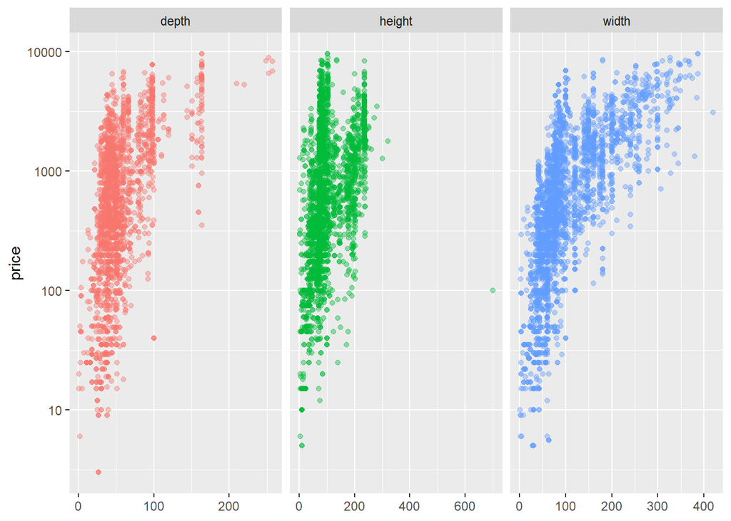

```r
ikea %>%
  select(...1, price, depth:width) %>%
  pivot_longer(depth:width, names_to = "dim") %>%
  ggplot(aes(value, price, color = dim)) +
  geom_point(alpha = 0.4, show.legend = FALSE) +
  scale_y_log10() +
  facet_wrap(~dim, scales = "free_x") +
  labs(x = NULL)
```

Transform data log-transform and convert to factors

```r
ikea_df <- ikea %>%
  select(price, name, category, depth, height, width) %>%
  mutate(price = log10(price)) %>%
  mutate_if(is.character, factor)

ikea_df
```

```
## # A tibble: 3,694 × 6
##    price name                  category      depth height width
##    <dbl> <fct>                 <fct>         <dbl>  <dbl> <dbl>
##  1  2.42 FREKVENS              Bar furniture    NA     99    51
##  2  3.00 NORDVIKEN             Bar furniture    NA    105    80
##  3  3.32 NORDVIKEN / NORDVIKEN Bar furniture    NA     NA    NA
##  4  1.84 STIG                  Bar furniture    50    100    60
##  5  2.35 NORBERG               Bar furniture    60     43    74
##  6  2.54 INGOLF                Bar furniture    45     91    40
##  7  2.11 FRANKLIN              Bar furniture    44     95    50
##  8  2.29 DALFRED               Bar furniture    50     NA    50
##  9  2.11 FRANKLIN              Bar furniture    44     95    50
## 10  3.34 EKEDALEN / EKEDALEN   Bar furniture    NA     NA    NA
## # ℹ 3,684 more rows
```

## Build a Model

split data

```r
library(tidymodels)
set.seed(123)
ikea_split <- initial_split(ikea_df, strata = price)
ikea_train <- training(ikea_split)
ikea_test  <- testing(ikea_split)

# Data are too small for cv
# rsample::vfold_cv(ikea_train)
set.seed(234)
ikea_folds <- rsample::bootstraps(ikea_train)
ikea_folds
```

```
## # Bootstrap sampling
## # A tibble: 25 × 2
##    splits              id
##    <list>              <chr>
##  1 <split [2770/995]>  Bootstrap01
##  2 <split [2770/1030]> Bootstrap02
##  3 <split [2770/1039]> Bootstrap03
##  4 <split [2770/1050]> Bootstrap04
##  5 <split [2770/1009]> Bootstrap05
##  6 <split [2770/1076]> Bootstrap06
##  7 <split [2770/1021]> Bootstrap07
##  8 <split [2770/1036]> Bootstrap08
##  9 <split [2770/991]>  Bootstrap09
## 10 <split [2770/984]>  Bootstrap10
## # ℹ 15 more rows
```

```r
library(usemodels)

usemodels::use_ranger(price ~ ., data = ikea_train)
```

```r
library(textrecipes)
ranger_recipe <-
  recipe(formula = price ~ ., data = ikea_train) %>%
    step_other(name, category, threshold = 0.01) %>%
    step_clean_levels(name, category) %>%
    step_impute_knn(depth, height, width)

ranger_spec <-
  rand_forest(mtry = tune(), min_n = tune(), trees = 1000) %>%
  set_mode("regression") %>%
  set_engine("ranger")

ranger_workflow <-
  workflow() %>%
  add_recipe(ranger_recipe) %>%
  add_model(ranger_spec)

set.seed(57439)
ranger_tune <-
  tune_grid(ranger_workflow,
            ikea_folds,
            grid = 2)
```

```
## i Creating pre-processing data to finalize unknown parameter: mtry
```

## Evaluate Models

1. View the best model

```r
show_best(ranger_tune, metric = "rmse")
```

```
## # A tibble: 2 × 8
##    mtry min_n .metric .estimator  mean     n std_err .config
##   <int> <int> <chr>   <chr>      <dbl> <int>   <dbl> <chr>
## 1     3     9 rmse    standard   0.336    25 0.00218 Preprocessor1_Model2
## 2     2    40 rmse    standard   0.353    25 0.00240 Preprocessor1_Model1
```

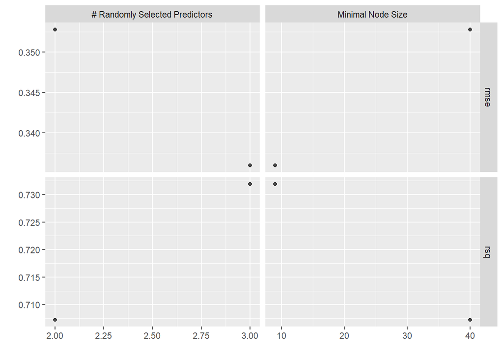

```r
autoplot(ranger_tune)
```

```r
final_ranger <- ranger_workflow %>%
    finalize_workflow(select_best(ranger_tune, metric = "rmse"))
```

3. Fit the best model to train data and evaluate on test data

```r
ikea_fit <- tune::last_fit(final_ranger, ikea_split)
```

4. Collect metrics

```r
tune::collect_metrics(ikea_fit)
```

```
## # A tibble: 2 × 4
##   .metric .estimator .estimate .config
##   <chr>   <chr>          <dbl> <chr>
## 1 rmse    standard       0.323 Preprocessor1_Model1
## 2 rsq     standard       0.744 Preprocessor1_Model1
```

5. Collect predictions

```r
tune::collect_predictions(ikea_fit)
```

```
## # A tibble: 924 × 5
##    id               .pred  .row price .config
##    <chr>            <dbl> <int> <dbl> <chr>
##  1 train/test split  2.44     4  1.84 Preprocessor1_Model1
##  2 train/test split  2.30     6  2.54 Preprocessor1_Model1
##  3 train/test split  2.16     9  2.11 Preprocessor1_Model1
##  4 train/test split  3.18    10  3.34 Preprocessor1_Model1
##  5 train/test split  2.50    15  2.54 Preprocessor1_Model1
##  6 train/test split  2.61    19  2.77 Preprocessor1_Model1
##  7 train/test split  2.21    20  2.17 Preprocessor1_Model1
##  8 train/test split  2.50    26  2.54 Preprocessor1_Model1
##  9 train/test split  2.95    30  2.74 Preprocessor1_Model1
## 10 train/test split  3.18    35  1.60 Preprocessor1_Model1
## # ℹ 914 more rows
```

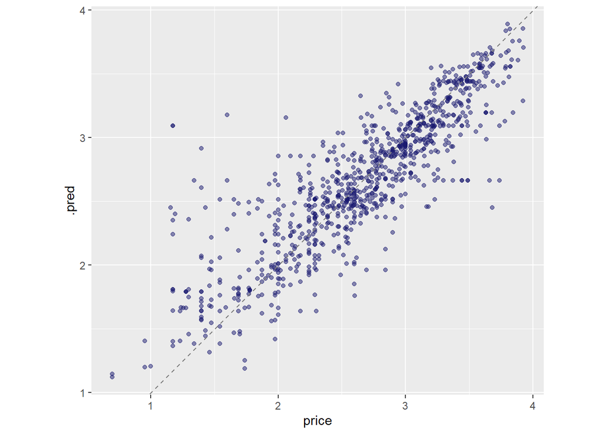

```r
collect_predictions(ikea_fit) %>%

    ggplot(aes(price, .pred)) +
    geom_point(alpha = 0.5, color = "midnightblue") +
    geom_abline(lty = 2, color = "gray50") +
    coord_fixed()
```

6. Predict

```r
ikea_fit %>%
    extract_workflow() %>%
    predict(ikea_test[1,])
```

```
## # A tibble: 1 × 1
##   .pred
##   <dbl>
## 1  2.44
```

7. View important variables

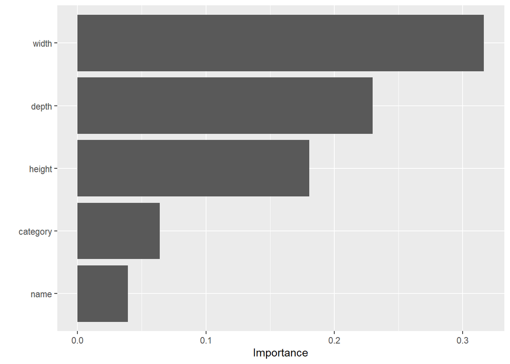

```r
library(vip)
imp_spec <- ranger_spec %>%
    tune::finalize_model(tune::select_best(ranger_tune)) %>%
    parsnip::set_engine("ranger", importance = "permutation")

workflows::workflow() %>%
    add_recipe(ranger_recipe) %>%
    add_model(imp_spec) %>%
    fit(ikea_train) %>%
    workflows::pull_workflow_fit() %>%
    vip()
```

### Question and Data

#### What is the research question?

#### Describe the data briefly.

#### Describe the first observation (the first row) in the data.

### Data Exploration and Transformation

#### What are the characteristics of the key variables used in the analysis? For example, which of the predictors seems to have correlations with the outcome variable? Does any variable have a skewed distribution, missing values, or incorrect information?

#### Describe the differences between the original data and the data transformed for modeling. Why?

### Data Preparation and Modeling

#### What are the names of data preparation steps (e.g., step_dummy) mentioned in the video?

#### What is the name of the machine learning models (e.g., random forest) used in the analysis?

#### Describe the steps taken for data preparation. Why?

#### Describe the characteristics of the models used in the analysis, including their advantages and disadvantages.

### Model Evaluation

#### What metrics are used in the model evaluation?

#### Describe the characteristics of the metrics used in the analysis, including their advantages and disadvantages.

### Conclusion

#### What are the major findings?